# Final Project - Analysis and Prediction on Movies

# 3. Conclusion

On this project, I tried to make a deep analysis and prediction on movies. I started by implementing some extended exploratory data analysis, in order to understand the dataset better. Mostly, I studied the correlation among variables and chose imdb_rating to be my dependent variable.

Next, I splitted the dataset into a training and testing set, so I could have the chance to test my prediction models. After this, I tried to build two prediction models. The first one was using the standard linear model function and the stepwise automated model selection algorithm, more specifically the AIC stepwise model selection. After this process, I constructed some accuracy and normality testing. In overall, the process was acceptable, and the variables selected were significant to the model.

The second model was built based on the feature engineering process. The feature engineering process was responsible in improving the adjusted R2 and the model seemed to generalize well in new unseen data, as we obtained a relatively low RMSE. I implemented some feature transformation, so the variables could have been more significant. The NZV and Correlation analysis taken with the final model eleminated some probable dependent columns. After selecting the final model, I tested the model, by comparing the RMSE for both testing and training set. They had almost similar values, so I can say the model responded positively.

In overall, both models were successful to make predictions. The most influential variables in the first model were significant in the second one also. If I have to pick among them, I would say Model Engineering. Feature engineering tries to transform raw data into features that better represent the underlying problem to the predictive models, resulting in improved model accuracy on unseen data.

Before the first raw model, I managed to extract a better model with the stepwise selection, after that, the criterious feature selection, transformation and engineering processes always gave a better fit in the training set.

In this project I picked ‘imdb_rating’ variable as a response variable. Similar analysis could be made using the other two continuous variables (‘critics_score’ and ‘audience_score’). Since all these three variables were highly correlated, I expect a similar response even if you consider critics_score or audience_score as a dependent variable. Moreover, I would like to mention that I tried to use support vector machines predicting the models, instead of linear models. I chose to work on linear models, because the model accuracy was almost the same in both cases. Linear Models are the most popular method on predicting multivariate covariates, but I wouldn’t exlude any other option. Since the results were almost the same, I prefered to use linear regression models in this case.

There is a lot of research that can be done and the one explained in this project shows that we can accurately predict how people will rate the movies from its general characteristics.

# Appendix

## Plot 1 - Movies Trend per year

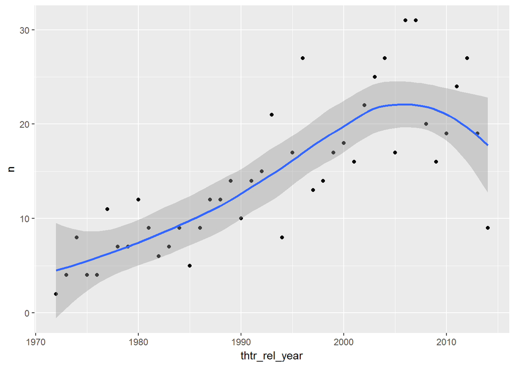

```r
# ggplot showing the trend of movies per year
temp <- movies %>% select(title,thtr_rel_year) # select only movie title and year released
temp <- temp %>% group_by(thtr_rel_year) %>% summarise(n=n()) # how many movies produced in a specific year
temp <- na.omit(temp)
ggplot(temp, aes(thtr_rel_year, n)) +  geom_point() +  geom_smooth()
```

## Plot 2 - Charts of data distribution

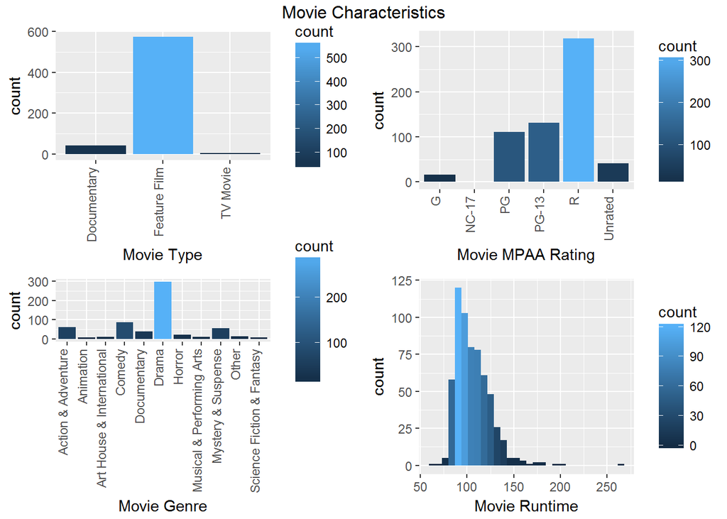

```r
# Create histograms of some of the key movie characteristic data.
p1 <- ggplot(data=movies, aes(x=genre)) +
      geom_bar(aes(fill = ..count..)) +
      xlab("Movie Genre") +
      theme(axis.text.x=element_text(angle=90, hjust=1, vjust=0))
p2 <- ggplot(data=movies, aes(x=title_type)) +
      geom_bar(aes(fill = ..count..)) +
      xlab("Movie Type") +
      theme(axis.text.x=element_text(angle=90, hjust=1, vjust=0))
p3 <- ggplot(data=movies, aes(x=mpaa_rating)) +
      geom_bar(aes(fill = ..count..)) +
      xlab("Movie MPAA Rating") +
      theme(axis.text.x=element_text(angle=90, hjust=1, vjust=0))
p4 <- ggplot(data=movies, aes(x=runtime)) +
      geom_histogram( aes(fill = ..count..)) +
      xlab("Movie Runtime")
grid.arrange(p2, p3, p1, p4, nrow=2,
             top="Movie Characteristics")
```

## Plot 3 - Correlation of all numeric variables.

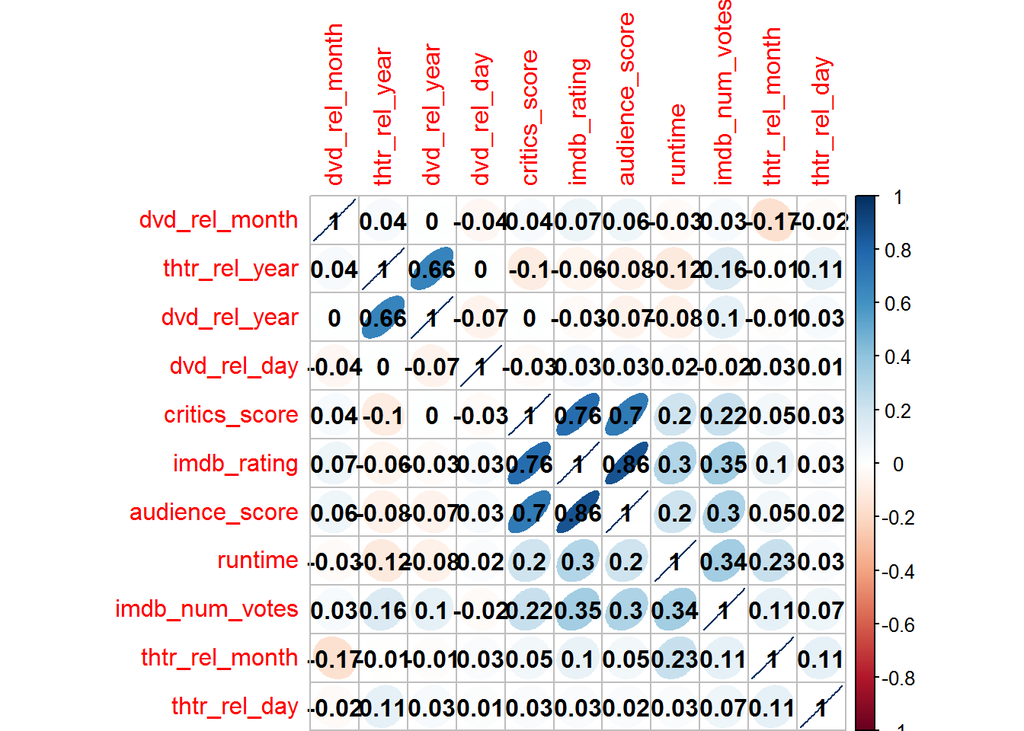

```r
# Data cleaning
movies <- na.omit(movies)
movies <- unique(movies)

# Correlation between numeric values
correlation <- cor(movies[sapply(movies, is.numeric)])
corrplot(correlation, order = "hclust", method = "ellipse", addCoef.col = "black")
```

## Plot 4 - Pairwise plots of movie rating scores

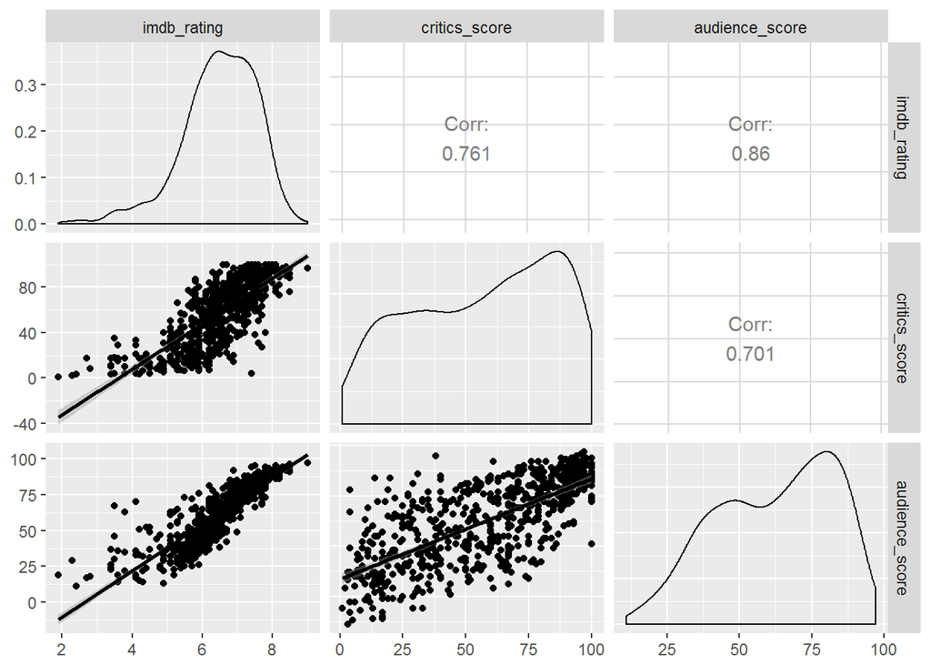

```r
# Create pairwise plots of the movie rating scores to test for colinearity.
responseCols <- c(13,16,18)
movies1 <- movies[,responseCols]
g = ggpairs(movies1, lower = list(continuous = "smooth"),method = "loess")
g
```

## Plot 5 - Histograms of movie rating scores

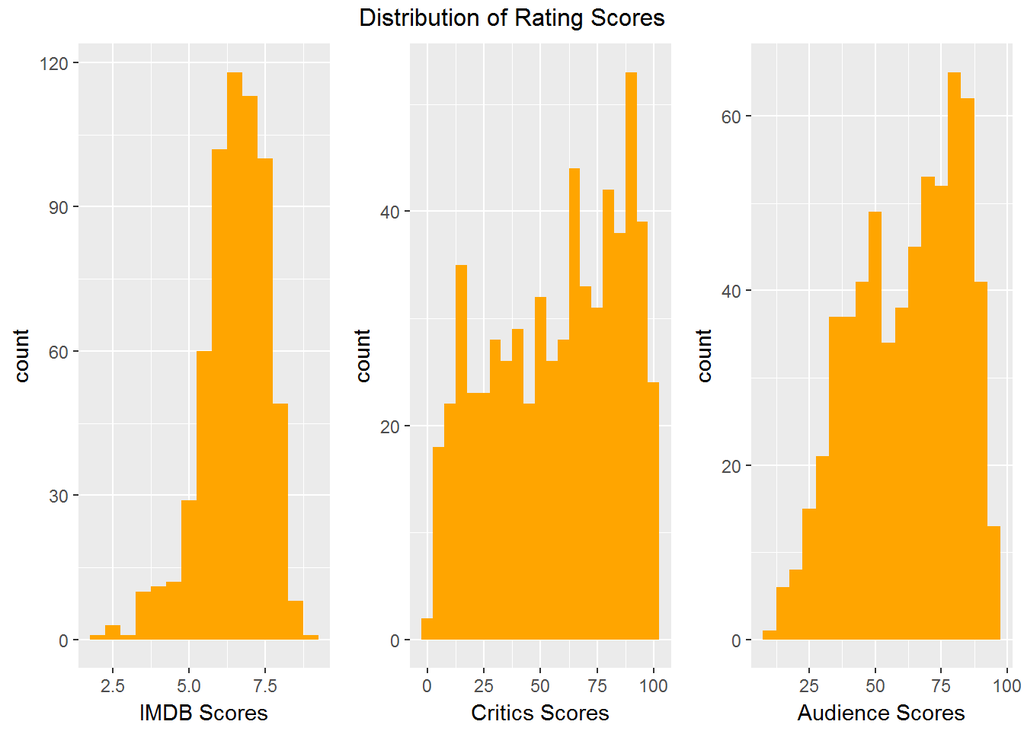

```r
# Create histograms of the movie rating scores.
p1 <- ggplot(data=movies, aes(x=imdb_rating)) +
      geom_histogram(binwidth=0.5, fill="orange") +
      xlab("IMDB Scores")
p2 <- ggplot(data=movies, aes(x=critics_score)) +
      geom_histogram(binwidth=5, fill="orange") +
      xlab("Critics Scores")
p3 <- ggplot(data=movies, aes(x=audience_score)) +
      geom_histogram(binwidth=5, fill="orange") +
      xlab("Audience Scores")
grid.arrange(p1, p2, p3, nrow=1,
             top="Distribution of Rating Scores")
```

## Plot 6 - Correlation of IMDB rating to other variables

```r
#remove critics_score and audience_score variables since we have studied them
movies$critics_score <- NULL
movies$audience_score <- NULL

#select numeric columns
movies %>% remove_missing()
```

```
## # A tibble: 618 × 30
##                     title   title_type              genre runtime
##                     <chr>       <fctr>             <fctr>   <dbl>
## 1             Filly Brown Feature Film              Drama      80
## 2                The Dish Feature Film              Drama     101
## 3     Waiting for Guffman Feature Film             Comedy      84
## 4    The Age of Innocence Feature Film              Drama     139
## 5             Malevolence Feature Film             Horror      90
## 6               Lady Jane Feature Film              Drama     142
## 7            Mad Dog Time Feature Film              Drama      93
## 8  Beauty Is Embarrassing  Documentary        Documentary      88
## 9    The Snowtown Murders Feature Film              Drama     119
## 10            Superman II Feature Film Action & Adventure     127
## # ... with 608 more rows, and 26 more variables: mpaa_rating <fctr>,
## #   studio <fctr>, thtr_rel_year <dbl>, thtr_rel_month <dbl>,
## #   thtr_rel_day <dbl>, dvd_rel_year <dbl>, dvd_rel_month <dbl>,
## #   dvd_rel_day <dbl>, imdb_rating <dbl>, imdb_num_votes <int>,
## #   critics_rating <fctr>, audience_rating <fctr>, best_pic_nom <fctr>,
## #   best_pic_win <fctr>, best_actor_win <fctr>, best_actress_win <fctr>,
## #   best_dir_win <fctr>, top200_box <fctr>, director <chr>, actor1 <chr>,
## #   actor2 <chr>, actor3 <chr>, actor4 <chr>, actor5 <chr>,
## #   imdb_url <chr>, rt_url <chr>
```

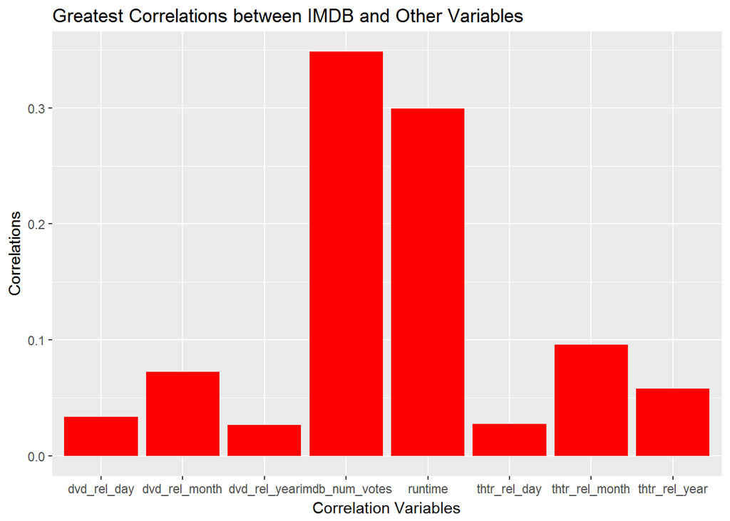

```r
nums <- sapply(movies, is.numeric)
#and here you have "the most important correlations" for variable cases excluding character variables
Movie_Corr <- movies[,nums]  %>% correlate() %>% focus(imdb_rating)
Bar_Corr <- ggplot(data=Movie_Corr, aes(x=rowname, y=abs(imdb_rating))) +
  geom_bar(stat="identity", position="identity", fill = "red") +
    scale_colour_solarized("red") +
  ylab("Correlations") +
  xlab("Correlation Variables") +
  ggtitle("Greatest Correlations between IMDB and Other Variables")

Bar_Corr
```

## Plot 7 - Number of users versus IMDB score

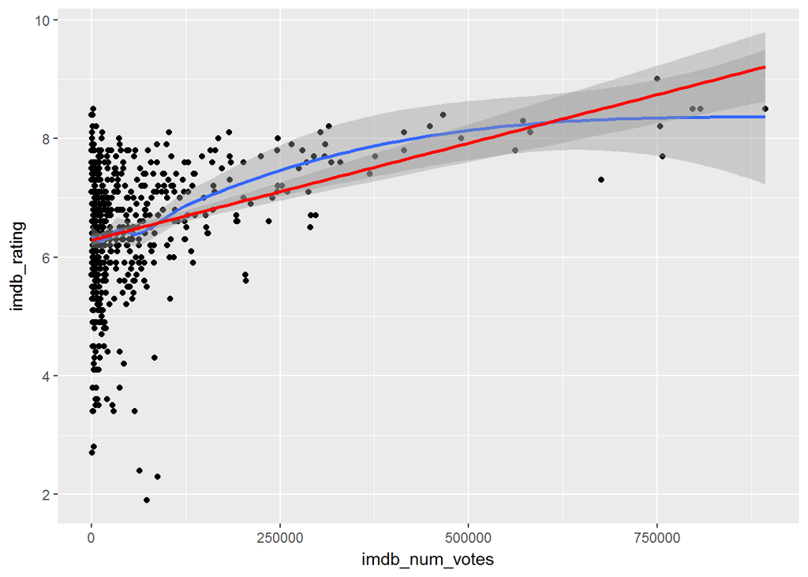

```r
ggplot(movies, aes(x = imdb_num_votes, y = imdb_rating)) + geom_point() + geom_smooth() +geom_smooth(method= "lm", color = "red")
```

## Plot 8 - Runtime versus IMDB rating

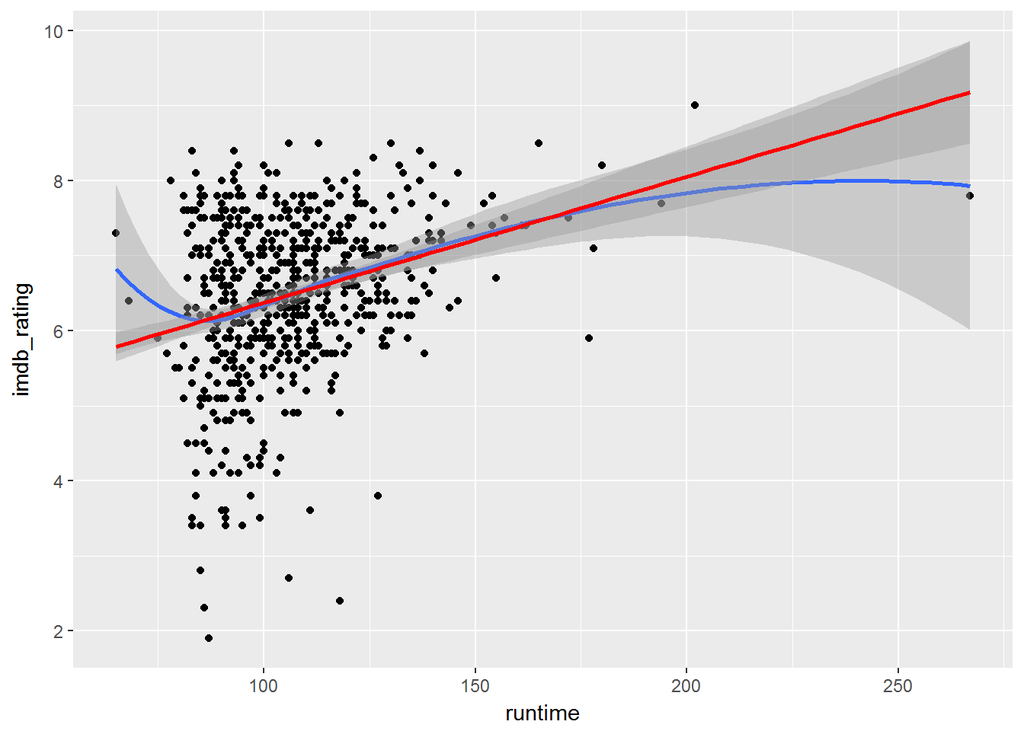

```r
ggplot(movies, aes(x = runtime, y = imdb_rating)) + geom_point() + geom_smooth() +geom_smooth(method= "lm", color = "red")
```

## Plot 9 - IMDB rating versus MPAA rating

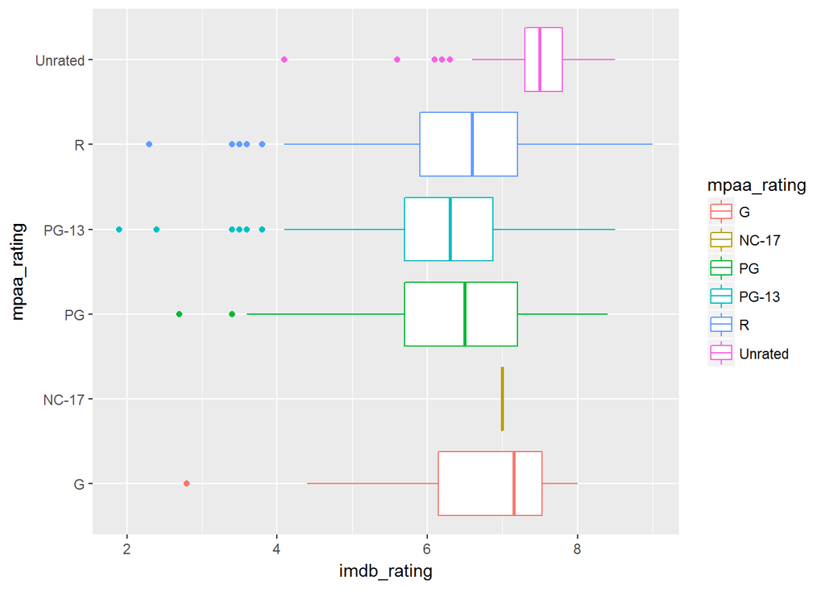

```r
# plot imdb rating based on mpaa_rating
rating <- movies %>% select(imdb_rating,mpaa_rating)
rating <- na.omit(rating)
rate <- ggplot(rating, aes(x=mpaa_rating, y = imdb_rating, colour=mpaa_rating)) + geom_boxplot() + coord_flip()
rate
```

## Plot 10 - Movies age vesus IMDB rating

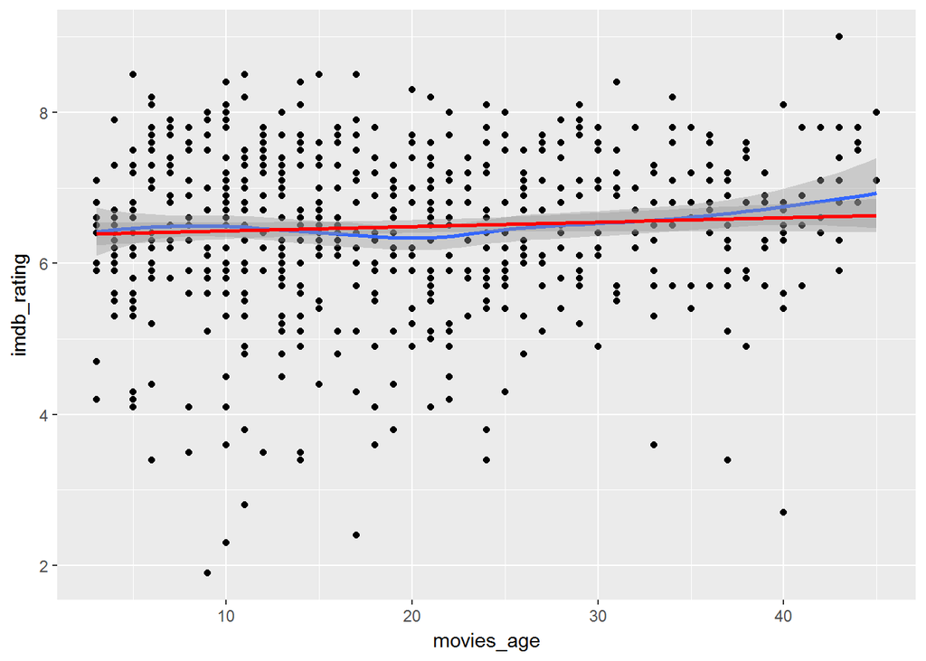

```r
# find movies age
current_year <- format(Sys.time(), " %Y")
movies$movies_age <- as.numeric(current_year)- movies$thtr_rel_year
# plot the relation
Score_Age <- ggplot(movies, aes(x = movies_age, y = imdb_rating)) + geom_point() + geom_smooth() +geom_smooth(method= "lm", color = "red")
Score_Age
```

## Plot 11 - Directors versus IMDB rating

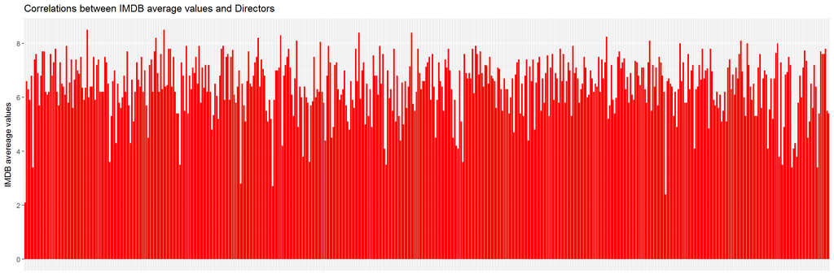

```r
## relationship of average imdb rating for each director
director <- movies %>% select(director,imdb_rating)
director <- director %>% group_by(director) %>% summarise(avg_imdb_rating=mean(imdb_rating))
director <- director %>% arrange(desc(avg_imdb_rating))
ggplot(data=director, aes(x=director, y=avg_imdb_rating)) +
  geom_bar(stat="identity", position="identity", fill = "red") +
    scale_colour_solarized("red") +
  ylab("IMDB avereage values") +
   ggtitle("Correlations between IMDB average values and Directors") +
    theme(axis.title.x=element_blank(),
        axis.text.x=element_blank(),
        axis.ticks.x=element_blank())
```

## Plot 12 - Residuals and Diagnostics for Model 1

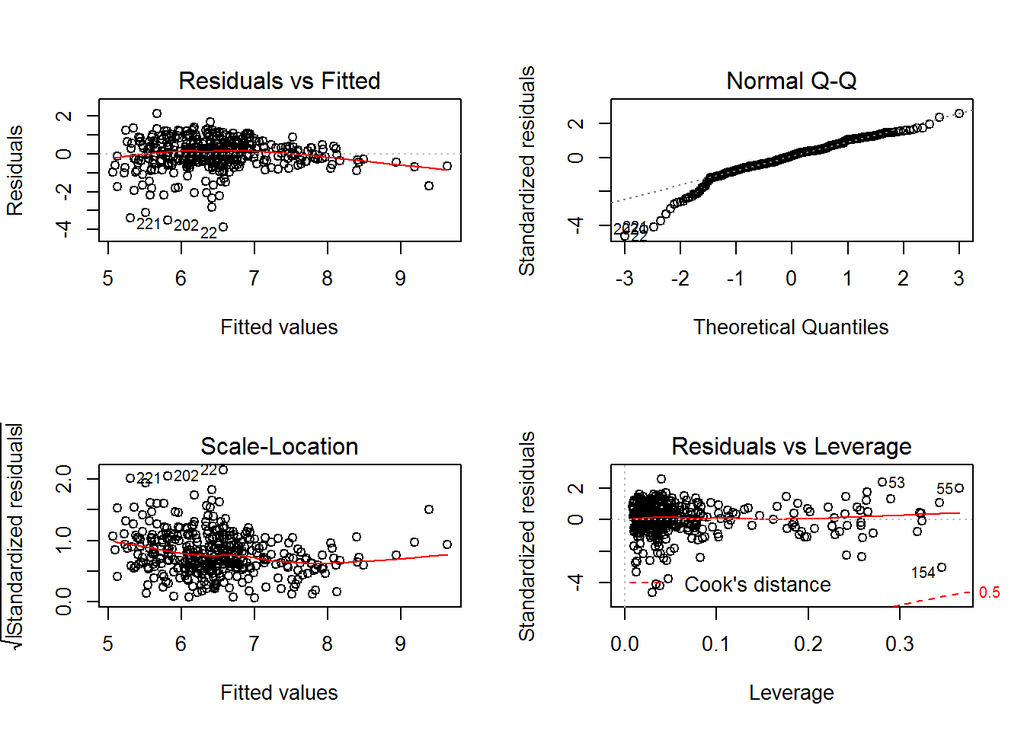

```r
# check residuals and diagnostics for the final model in AIC
par(mfrow = c(2, 2))
plot(final.model)
```

## Plot 13 - Predicted versus truth in test set for Model 1

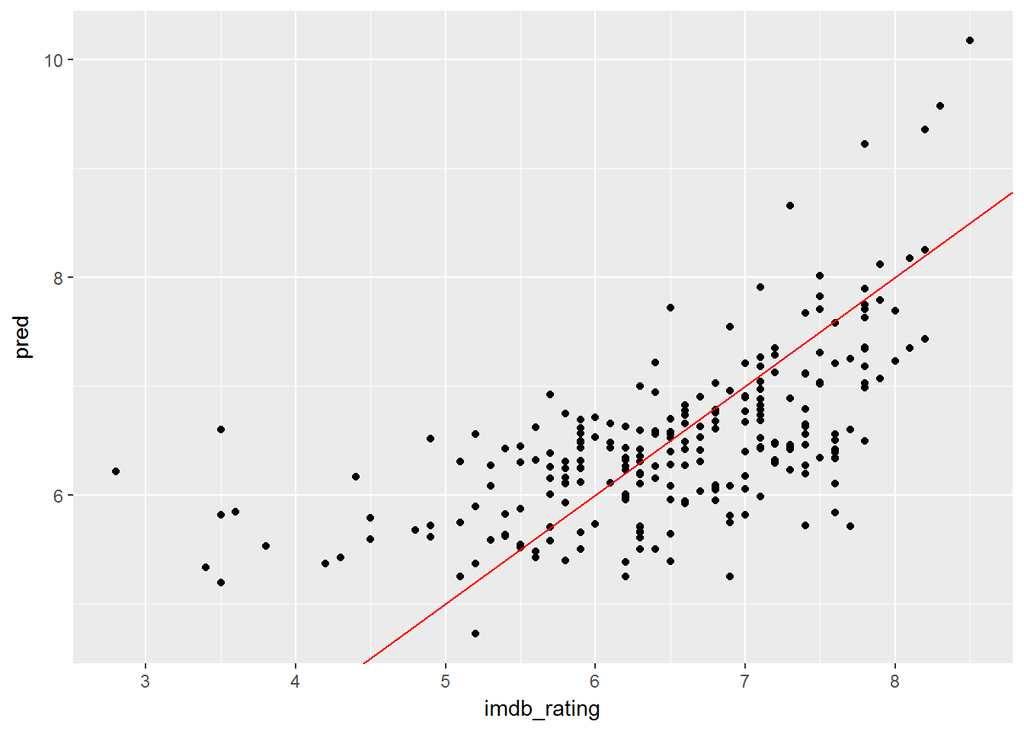

```r
set.seed(123)
# check the imdb rating versus the testing prediction in Model 1
# they are lineary related which makes the testing confidential
pred <- predict(final.model, testing)
p <-ggplot(data = testing, aes(x=imdb_rating, y = pred)) + geom_point()
p + geom_abline(slope=1, intercept=0, colour = "red")
```

## Plot 14 - Residuals and Diagnostics for Model 2

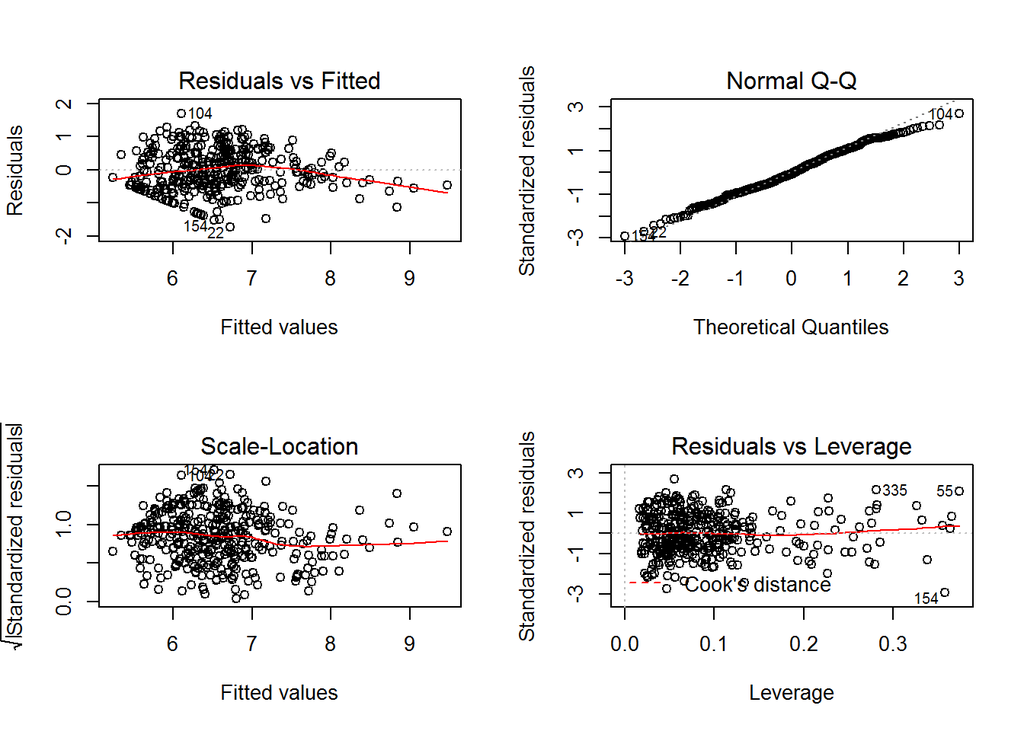

```r
# check residuals and diagnostics for the final model in AIC
par(mfrow = c(2, 2))
plot(finalModEng)
```

## Plot 15 - Predicted versus truth in test set for Model 2

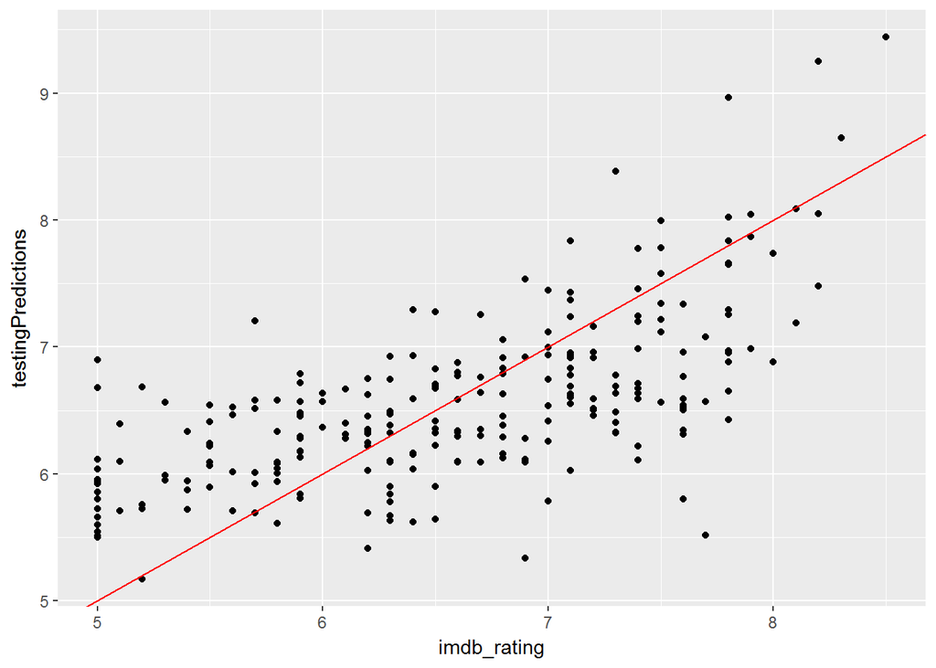

```r
set.seed(123)
# check the imdb rating versus the testing prediction in Model 2
# they are lineary related which makes the testing confidential
p <-ggplot(data = TestingPredictors, aes(x=imdb_rating, y = testingPredictions)) + geom_point()
p + geom_abline(slope=1, intercept=0, colour = "red")
```